# General BMD reporting

IBBruns

2024-07-04

# Settings

## Manually set parameters

Here you assign which analysis you have performed

```r
# choose project
studyNR = "EUT046"

# did you run the BMD also for log2fc values? If yes: TRUE, else: FALSE
runBMDonLog2fc = TRUE

# did you perform a williams trend test and do you have the output? If yes:
# TRUE, else: FALSE
williamsTrendTest = TRUE

# did you run the BMD on pathway enrichment scores? If yes: TRUE, else: FALSE
# (NOTE: if you determine pathway BMDs based on the median gene BMD assign
# FALSE)
runBMDonNetworkScores = TRUE

# did you upload enrichment scores (e.g. eigengene scores/normalized enrichment
# scores)
upload_enrichmentScores = TRUE
```

## Load packages

```r
pacman::p_load(tidyverse, ggfortify, gridExtra, pheatmap, plotly, DT, knitr, cowplot,
    kableExtra)
```

## Set directories

```r
# data directory
if (!dir.exists(paste0("data/"))) {
    dir.create(path = file.path(getwd(), "data"))
}
dataDir <- file.path(getwd(), "data")

# input directory
if (!dir.exists(paste0("input/", studyNR, "/RODAF/"))) {
    dir.create(path = file.path(getwd(), "input", studyNR, "RODAF"))
}
inputDir <- file.path(getwd(), "input", studyNR, "RODAF")
```

## Import data

Load data, we need:  
REQUIRED:  
1. `sample_metadata` = metadata provided with the raw data  
2. `normalized_counts` = normalized counts (e.g. CPM or log2CPM). sample_id should be as column names, Probe_ID in the first column, so genes as rows.  
3. `pathway_overview` = overview of which gene belongs to which pathway. Data should contain the following columns: Probe_ID, pathway.  
4. `BMD_output_normalized_counts` = output van BMD modeling. Data should at least contain the following columns: Probe_ID, Best.BMD (this can also be the average BMD of all your models), Best.BMDL (BMDL from your best model (or average)), Best.BMDU, Best.R.Squared. NOTE: these are needed to apply the filters I did, if you want to apply different filters, you need different columns, can be adjusted in the code.  
5. `medianBMD_pathways_normalized_counts` = median BMD for genes in your assessed pathways. Data should contain at least the following columns: Genes.That.Passed.All.Filters (which indicates the number of genes per pathway after all selection criteria), Pathway.Name containing the names of the pathways.

OPTIONAL:  
6. `WTT_normalized_counts` = Williams Trend Test output (only needed when WilliamsTrendTest = TRUE). Here at least the following columns are necessary: Max.Fold.Change (indicates the direction of the response (i.e. up- or downregulation)), Unadjusted.P.Value, Adjusted.P.Value (depending on which filter you want to apply).  
7. `enrichment_scores` = enrichment scores (e.g. normalized enrichment scores after performing a GSEA or eigengene scores). Data should contain the following columns: sample_id, pathway, enrichment_score.

NOTE:  
if runBMDonLog2fc = TRUE, we also need the following input:  
8. `log2fc` = log2fc values. The following columns are needed: sample_id, Probe_ID, log2fc.  
9. `BMD_output_log2fc` = BMD output when ran on log2fc values.  
10. `WTT_log2fc` = WTT output when ran on log2fc values (optional).

if runBMDonNetworkScores = TRUE, we also need the following input:  
11. `BMD_output_pathway` = BMD output when ran on pathway enrichment scores  
12. `WTT_pathway` = WTT output when ran on pathway enrichment scores (optional).

```r
load(file.path(inputDir, "R-ODAF_DESeq2_output_files.RData"))

# here load the pathway gene association; one column all Probe_ID, other column pathway association.
pathway_overview = read.delim(file.path(inputDir, paste0(studyNR, "_gene_module_overview.txt"))) %>%
  mutate(
    gene_symbol = gsub("id_", "", gene_symbol),
    entrez_id = gsub("id_", "", entrez_id)
  ) %>%
  distinct(gene_symbol, module) %>%
  dplyr::rename("pathway" = module)


if(upload_enrichmentScores){
  # here load eigengene scores/NES scores: column names are sample_id, pathway and enrichment_score
enrichment_scores =  read.delim(file.path(inputDir, paste0(studyNR, "_R-ODAF_TXGMAPr_module_egs.txt"))) %>%
  dplyr::rename("enrichment_score" = eg_score,
                "pathway" = module) %>%
  select(sample_id, pathway, enrichment_score)
}


if(runBMDonLog2fc){
  log2fc = expression_long # load log2fc values in long format (sample_id, gene_symbol_entrez_id, log2fc, pvalue, padj)

  if(williamsTrendTest){
    WTT_log2fc = read.delim(file.path(inputDir, paste0(studyNR, "_RODAF_log2fc_WTT_output.txt"))) %>%
    mutate(timepoint = str_extract(Analysis, "\\d+hr"))
  }

  BMD_output_log2fc = read.delim(file.path(inputDir, paste0(studyNR, "_RODAF_log2fc_BMD_output.txt"))) %>%
  mutate(timepoint = str_extract(Analysis, "\\d+hr")) %>%
    separate("Probe.ID", into=c("gene_symbol", "probe_NR"), remove = FALSE, sep="_") %>%
  left_join(pathway_overview, by = "gene_symbol") %>% # add the pathway assignment to each gene
  select(-"gene_symbol", -"probe_NR")

  # medianBMD_pathways_log2fc = read.delim(file.path(inputDir, paste0(studyNR, "_log2fc_functionalClas_output.txt"))) %>%
  # mutate(timepoint = str_extract(Analysis, "\\d+hr")) %>% dplyr::rename("Pathway.Name" = GO.Pathway.Gene.Set.Gene.Name)
}



if(runBMDonNetworkScores) {
  BMD_output_pathway = read.delim(file.path(inputDir, paste0(studyNR, "_RODAF_module_egs_BMD_output.txt"))) %>%
    mutate(timepoint = str_extract(Analysis, "\\d+hr"))

  if (williamsTrendTest) {
    WTT_pathway = read.delim(file.path(inputDir, paste0(
      studyNR, "_RODAF_module_egs_WTT_output.txt"
    ))) %>%
      mutate(timepoint = str_extract(Analysis, "\\d+hr"))
  }
}


# txgmapr_enrichment = readRDS(file.path(dataDir, "module_enrichment.rds"))
#
# txgmapr_tf_enrichment = readRDS(file.path(dataDir, "tf_enrichment.rds"))
```

# Williams Trend Test (WTT)

```r
doseresponsives_plot = function(WTToutput, level) {

    # add timepoint and regulation to data
    WTToutput = WTToutput %>%
        mutate(regulation = if_else(WTToutput$Max.Fold.Change > 0, true = "upregulated",
            false = "downregulated")) %>%
        filter(Unadjusted.P.Value < 0.05)

    # make sure that all timepoints are in final figure (also timepoints
    # without significant dose/responses)
    all_combinations <- expand.grid(timepoint = c("4hr", "8hr", "16hr", "24hr", "48hr",
        "72hr"), regulation = WTToutput %>%
        pull(regulation) %>%
        unique())

    counts = WTToutput %>%
        group_by(timepoint, regulation) %>%
        summarize(count = n()) %>%
        right_join(all_combinations, by = c("timepoint", "regulation")) %>%
        mutate(count = coalesce(count, 0))

    # change timepoint to hours
    counts$timepoint = gsub("hr", "", counts$timepoint)
    counts$timepoint = paste0(counts$timepoint, "_hours")
    counts$timepoint = factor(counts$timepoint, levels = c("4_hours", "8_hours",
        "16_hours", "24_hours", "48_hours", "72_hours"))

    # create a barplot
    ggplot(counts, aes(x = timepoint, y = count, fill = regulation)) + geom_bar(stat = "identity",
        position = "stack") + labs(title = paste0("Number of dose responsive ", level,
        " per timepoint"), x = "", y = paste0("Number of dose responsive ", level)) +
        scale_fill_manual(values = c(upregulated = "firebrick", downregulated = "darkblue"),
            name = "Regulation")
}
```

## Gene level

### log2fc

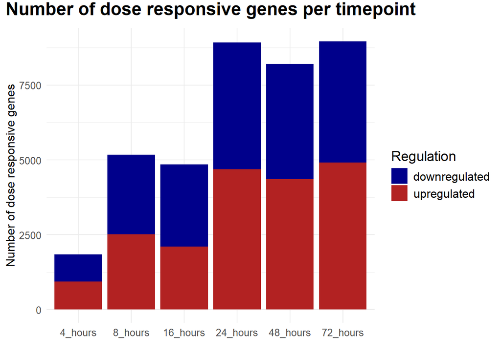

```r
if (williamsTrendTest & runBMDonLog2fc) {
    doseresponsives_plot(WTToutput = WTT_log2fc, level = "genes")
}
```

## Network level

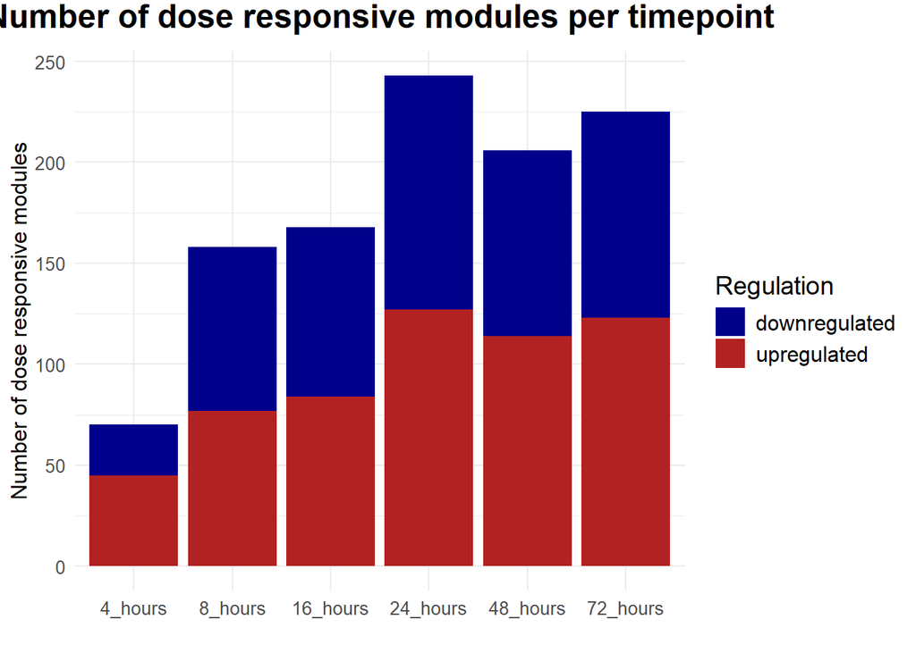

```r
if (williamsTrendTest & runBMDonNetworkScores) {
    doseresponsives_plot(WTToutput = WTT_pathway, level = "modules")
}
```

# Benchmark Dose Analysis

## BMD accumulation plot

Interactive plot to visualize the accumulative benchmark doses. Here, we also filter the BMD output for: Best.BMD.BMDL < 20  
Best.BMDU.BMD < 20 Best.RSquared >= 0.8 Best.BMD >= 0.1*lowest concentration <= highest concentration

### Filter BMD data

#### Set function

```r
filterBMDoutput = function(BMDoutput) {

    lowest_conc = 0.1
    highest_conc = 50

    BMDoutput %>%
        filter(Best.BMD.BMDL < 20 & Best.BMDU.BMD < 20 & Best.RSquared >= 0.8 & Best.BMD >=
            0.1 * lowest_conc & Best.BMD <= highest_conc) -> BMDoutputFilter

    return(BMDoutputFilter)
}
```

#### Filter data

```r
if (runBMDonLog2fc) {
    BMD_output_log2fc_filter = filterBMDoutput(BMDoutput = BMD_output_log2fc)
}

if (runBMDonNetworkScores) {
    BMD_output_pathway_filter = filterBMDoutput(BMDoutput = BMD_output_pathway)
}
```

```r
BMDaccumulationPlot = function(BMDoutput, timepoint_oi, level) {

    if (level == "gene") {
        hover = "gene: "
    }
    if (level == "pathway") {
        hover = "pathway: "
    }

    BMDoutput %>%
        separate(Probe.ID, into = c("gene_symbol", "probe_NR"), sep = "_") %>%
        filter(timepoint == timepoint_oi) %>%
        arrange(Best.BMD) %>%
        ggplot(aes(Best.BMD, y = cumsum(Best.BMD), text = paste0(hover, gene_symbol))) +
        geom_point(stat = "identity") + scale_x_log10() + labs(title = paste0("BMD accumulation plot after ",
        timepoint_oi), y = "Cumulative BMD", x = "BMD")
}
```

### Gene level

#### log2fc

```r
if (runBMDonLog2fc) {
    BMDaccumulationPlot(BMDoutput = BMD_output_log2fc_filter, timepoint_oi = "4hr",
        level = "gene") %>%
        ggplotly() %>%
        print()
    BMDaccumulationPlot(BMDoutput = BMD_output_log2fc_filter, timepoint_oi = "8hr",
        level = "gene") %>%
        ggplotly() %>%
        print()
    BMDaccumulationPlot(BMDoutput = BMD_output_log2fc_filter, timepoint_oi = "16hr",
        level = "gene") %>%
        ggplotly() %>%
        print()
    BMDaccumulationPlot(BMDoutput = BMD_output_log2fc_filter, timepoint_oi = "24hr",
        level = "gene") %>%
        ggplotly() %>%
        print()
    BMDaccumulationPlot(BMDoutput = BMD_output_log2fc_filter, timepoint_oi = "48hr",
        level = "gene") %>%
        ggplotly() %>%
        print()
    BMDaccumulationPlot(BMDoutput = BMD_output_log2fc_filter, timepoint_oi = "72hr",
        level = "gene") %>%
        ggplotly() %>%
        print()

}
```

[output not shown]

### Network level

```r
if (runBMDonNetworkScores) {
    BMDaccumulationPlot(BMDoutput = BMD_output_pathway_filter, timepoint_oi = "4hr",
        level = "pathway") %>%
        ggplotly() %>%
        print()
    BMDaccumulationPlot(BMDoutput = BMD_output_pathway_filter, timepoint_oi = "8hr",
        level = "pathway") %>%
        ggplotly() %>%
        print()
    BMDaccumulationPlot(BMDoutput = BMD_output_pathway_filter, timepoint_oi = "16hr",
        level = "pathway") %>%
        ggplotly() %>%
        print()
    BMDaccumulationPlot(BMDoutput = BMD_output_pathway_filter, timepoint_oi = "24hr",
        level = "pathway") %>%
        ggplotly() %>%
        print()
    BMDaccumulationPlot(BMDoutput = BMD_output_pathway_filter, timepoint_oi = "48hr",
        level = "pathway") %>%
        ggplotly() %>%
        print()
    BMDaccumulationPlot(BMDoutput = BMD_output_pathway_filter, timepoint_oi = "72hr",
        level = "pathway") %>%
        ggplotly() %>%
        print()

}
```

[output not shown]

## Analyse BMD of most sensitive genes

### Define functions for different methods

#### 5th percentile

Gene closest to the 5th percentile of the BMD distribution; conservative metric value for the tPOD that targets the most responsive genes that may contribute to the toxicological response

```r
timepoints = c("4hr", "8hr", "16hr", "24hr", "48hr", "72hr")


get_5thpercentile = function(BMDoutput) {
    output_df = list()

    for (time in timepoints) {
        BMDoutput_timeoi = BMDoutput %>%
            filter(timepoint == time)

        target_BMD = quantile(BMDoutput_timeoi$Best.BMD, 0.05)
        closest_df = BMDoutput_timeoi %>%
            mutate(difference = abs(Best.BMD - target_BMD)) %>%
            arrange(difference) %>%
            head(1)
        closest_gene = closest_df %>%
            pull(Probe.ID)
        closest_BMD = closest_df %>%
            pull(Best.BMD)
        output_df[[time]] = data.frame(closest_gene, closest_BMD)
    }
    return(output_df)
}



if (runBMDonLog2fc) {
    percentile_log2fc = get_5thpercentile(BMDoutput = BMD_output_log2fc_filter)
}


if (runBMDonNetworkScores) {
    percentile_pathway = get_5thpercentile(BMDoutput = BMD_output_pathway_filter)
}
```

#### 25th lowest ranked gene

The 25th rank ordered gene’s BMD isset as theshold, which indicates where a defined change in the transcriptome has occurred

```r
get_25thranked = function(BMDoutput) {
    output_df = list()

    for (time in timepoints) {
        BMDoutput_timeoi = BMDoutput %>%
            filter(timepoint == time)

        ranked_df = BMDoutput_timeoi %>%
            arrange(Best.BMD) %>%
            dplyr::slice(25)
        ranked_gene = ifelse((nrow(ranked_df) == 0), NA, ranked_df %>%
            pull(Probe.ID))
        ranked_BMD = ifelse((nrow(ranked_df) == 0), NA, ranked_df %>%
            pull(Best.BMD))
        output_df[[time]] = data.frame(ranked_gene, ranked_BMD)

    }
    return(output_df)

}



if (runBMDonLog2fc) {
    ranked_log2fc = get_25thranked(BMDoutput = BMD_output_log2fc_filter)
}


if (runBMDonNetworkScores) {
    ranked_pathway = get_25thranked(BMDoutput = BMD_output_pathway_filter)
}
```

#### Lowest Consistent Reponse Dose (LCRD)

The LCRD is identified as the lowest BMC in a rank order of gene BMCs where all subsequent ratio values from adjacently ranked BMCs are within 1.66 (thereby eliminating unrealistically low gene BMCs that may be biological noise).

```r
get_LCRD = function(BMDoutput) {
    output_df = list()

    for (time in timepoints) {
        BMDoutput_timeoi = BMDoutput %>%
            filter(timepoint == time)

        if (nrow(BMDoutput_timeoi) >= 2) {
            # step 1: sort BMD by Best.BMD
            BMD_output_sort <- BMDoutput_timeoi %>%
                arrange(Best.BMD)

            # Inititalize variables
            current_group <- BMD_output_sort$Best.BMD
            largest_crgb <- current_group

            # loop through sorted BMDs
            for (i in 2:length(BMD_output_sort$Best.BMD)) {
                # calculate ratio
                BMD_ratio = BMD_output_sort$Best.BMD[i]/BMD_output_sort$Best.BMD[i -
                  1]

                if (BMD_ratio <= 1.66) {
                  current_group = c(current_group, BMD_output_sort$Best.BMD[i])
                } else {
                  # check if current group is larger than largets found so far
                  if (length(current_group) > length(largest_crgb)) {
                    largest_crgb <- current_group
                  }
                  # start new group
                  current_group = BMD_output_sort$Best.BMD[i]
                }

                # final check to ensure the last group is considered
                if (length(current_group) > length(largest_crgb)) {
                  largest_crgb <- current_group
                }

                # determine LCRD
                LCRD_BMD <- min(largest_crgb)

                # extract genes in largest CRGB
                genes_in_largest_crgb <- BMD_output_sort[BMD_output_sort$Best.BMD %in%
                  largest_crgb, ] %>%
                  pull(Probe.ID)
            }
        } else {
            LCRD_BMD = NA
            genes_in_largest_crgb = NA
        }
        output_df[[time]] = data.frame(CRGB_lowest_gene = genes_in_largest_crgb[1],
            LCRD_BMD)
    }
    return(output_df)
}






if (runBMDonLog2fc) {
    LCRD_log2fc = get_LCRD(BMDoutput = BMD_output_log2fc_filter)
}


if (runBMDonNetworkScores) {
    LCRD_pathway = get_LCRD(BMDoutput = BMD_output_pathway_filter)
}
```

#### First mode

The first mode is defined as the first point at which the first derivative changes from positive to negative with a negative second derivative (second derivative test).

```r
get_firstMode = function(BMDoutput) {
    output_df = list()

    for (time in timepoints) {
        BMDoutput_timeoi = BMDoutput %>%
            filter(timepoint == time)

        if (nrow(BMDoutput_timeoi) >= 2) {
            density_estimate = density(BMDoutput_timeoi$Best.BMD)

            # compute derivatives
            first_derivative = diff(density_estimate$y)/diff(density_estimate$x)
            second_derivative = diff(first_derivative)/diff(density_estimate$x[-1])

            # identify first mode
            first_mode_index <- NULL

            for (i in 2:(length(first_derivative) - 1)) {
                if (first_derivative[i - 1] > 0 && first_derivative[i] < 0 && second_derivative[i] <
                  0) {
                  first_mode_index <- i
                }
            }

            if (!is.null(first_mode_index)) {
                first_mode <- density_estimate$x[first_mode_index]

                # match BMD and gene (find closest BMD value to first mode)
                closest_BMD_index = which.min(abs(BMDoutput_timeoi$Best.BMD - first_mode))
                closest_bmd = BMDoutput_timeoi$Best.BMD[closest_BMD_index]
                gene_name = BMDoutput_timeoi$Probe.ID[closest_BMD_index]

            }

        } else {
            closest_bmd = NA
            gene_name = NA
        }

        # output BMD and gene name
        output_df[[time]] = data.frame(firstMode_BMD = closest_bmd, firstMode_gene = gene_name)
    }
    return(output_df)
}



if (runBMDonLog2fc) {
    firstMode_log2fc = get_firstMode(BMDoutput = BMD_output_log2fc_filter)
}


if (runBMDonNetworkScores) {
    firstMode_pathway = get_firstMode(BMDoutput = BMD_output_pathway_filter)
}
```

### Create table

#### Design function

First design function to generate table

```r
createBMDtable = function(percentile_list, ranked_list, LCRD_list, firstMode_list) {
    data_matrix <- matrix(NA, nrow = 6, ncol = 8, dimnames = list(paste0(timepoints),
        c("5th_percentile_gene", "5th_percentile_BMD", "25th_ranked_gene", "25th_ranked_BMD",
            "LCRD_gene", "LCRD_BMD", "first_mode_gene", "first_mode_BMD")))

    # Assign values to the matrix genes 5th percentile
    data_matrix[timepoints[1], "5th_percentile_gene"] <- percentile_list[[1]]$closest_gene
    data_matrix[timepoints[2], "5th_percentile_gene"] <- percentile_list[[2]]$closest_gene
    data_matrix[timepoints[3], "5th_percentile_gene"] <- percentile_list[[3]]$closest_gene
    data_matrix[timepoints[4], "5th_percentile_gene"] <- percentile_list[[4]]$closest_gene
    data_matrix[timepoints[5], "5th_percentile_gene"] <- percentile_list[[5]]$closest_gene
    data_matrix[timepoints[6], "5th_percentile_gene"] <- percentile_list[[6]]$closest_gene

    # BMD 5th percentile
    data_matrix[timepoints[1], "5th_percentile_BMD"] <- percentile_list[[1]]$closest_BMD
    data_matrix[timepoints[2], "5th_percentile_BMD"] <- percentile_list[[2]]$closest_BMD
    data_matrix[timepoints[3], "5th_percentile_BMD"] <- percentile_list[[3]]$closest_BMD
    data_matrix[timepoints[4], "5th_percentile_BMD"] <- percentile_list[[4]]$closest_BMD
    data_matrix[timepoints[5], "5th_percentile_BMD"] <- percentile_list[[5]]$closest_BMD
    data_matrix[timepoints[6], "5th_percentile_BMD"] <- percentile_list[[6]]$closest_BMD

    # genes 25th ranked
    data_matrix[timepoints[1], "25th_ranked_gene"] <- ranked_list[[1]]$ranked_gene
    data_matrix[timepoints[2], "25th_ranked_gene"] <- ranked_list[[2]]$ranked_gene
    data_matrix[timepoints[3], "25th_ranked_gene"] <- ranked_list[[3]]$ranked_gene
    data_matrix[timepoints[4], "25th_ranked_gene"] <- ranked_list[[4]]$ranked_gene
    data_matrix[timepoints[5], "25th_ranked_gene"] <- ranked_list[[5]]$ranked_gene
    data_matrix[timepoints[6], "25th_ranked_gene"] <- ranked_list[[6]]$ranked_gene

    # BMD 25th ranked
    data_matrix[timepoints[1], "25th_ranked_BMD"] <- ranked_list[[1]]$ranked_BMD
    data_matrix[timepoints[2], "25th_ranked_BMD"] <- ranked_list[[2]]$ranked_BMD
    data_matrix[timepoints[3], "25th_ranked_BMD"] <- ranked_list[[3]]$ranked_BMD
    data_matrix[timepoints[4], "25th_ranked_BMD"] <- ranked_list[[4]]$ranked_BMD
    data_matrix[timepoints[5], "25th_ranked_BMD"] <- ranked_list[[5]]$ranked_BMD
    data_matrix[timepoints[6], "25th_ranked_BMD"] <- ranked_list[[6]]$ranked_BMD

    # genes LCRD
    data_matrix[timepoints[1], "LCRD_gene"] <- LCRD_list[[1]]$CRGB_lowest_gene
    data_matrix[timepoints[2], "LCRD_gene"] <- LCRD_list[[2]]$CRGB_lowest_gene
    data_matrix[timepoints[3], "LCRD_gene"] <- LCRD_list[[3]]$CRGB_lowest_gene
    data_matrix[timepoints[4], "LCRD_gene"] <- LCRD_list[[4]]$CRGB_lowest_gene
    data_matrix[timepoints[5], "LCRD_gene"] <- LCRD_list[[5]]$CRGB_lowest_gene
    data_matrix[timepoints[6], "LCRD_gene"] <- LCRD_list[[6]]$CRGB_lowest_gene

    # BMD LCRD
    data_matrix[timepoints[1], "LCRD_BMD"] <- LCRD_list[[1]]$LCRD_BMD
    data_matrix[timepoints[2], "LCRD_BMD"] <- LCRD_list[[2]]$LCRD_BMD
    data_matrix[timepoints[3], "LCRD_BMD"] <- LCRD_list[[3]]$LCRD_BMD
    data_matrix[timepoints[4], "LCRD_BMD"] <- LCRD_list[[4]]$LCRD_BMD
    data_matrix[timepoints[5], "LCRD_BMD"] <- LCRD_list[[5]]$LCRD_BMD
    data_matrix[timepoints[6], "LCRD_BMD"] <- LCRD_list[[6]]$LCRD_BMD

    # genes LCRD
    data_matrix[timepoints[1], "first_mode_gene"] <- firstMode_list[[1]]$firstMode_gene
    data_matrix[timepoints[2], "first_mode_gene"] <- firstMode_list[[2]]$firstMode_gene
    data_matrix[timepoints[3], "first_mode_gene"] <- firstMode_list[[3]]$firstMode_gene
    data_matrix[timepoints[4], "first_mode_gene"] <- firstMode_list[[4]]$firstMode_gene
    data_matrix[timepoints[5], "first_mode_gene"] <- firstMode_list[[5]]$firstMode_gene
    data_matrix[timepoints[6], "first_mode_gene"] <- firstMode_list[[6]]$firstMode_gene

    # BMD firstMode
    data_matrix[timepoints[1], "first_mode_BMD"] <- firstMode_list[[1]]$firstMode_BMD
    data_matrix[timepoints[2], "first_mode_BMD"] <- firstMode_list[[2]]$firstMode_BMD
    data_matrix[timepoints[3], "first_mode_BMD"] <- firstMode_list[[3]]$firstMode_BMD
    data_matrix[timepoints[4], "first_mode_BMD"] <- firstMode_list[[4]]$firstMode_BMD
    data_matrix[timepoints[5], "first_mode_BMD"] <- firstMode_list[[5]]$firstMode_BMD
    data_matrix[timepoints[6], "first_mode_BMD"] <- firstMode_list[[6]]$firstMode_BMD

    # Convert the matrix to a data frame
    headers <- as.data.frame(data_matrix)

    # Use the kable function to create the table with grouped headers and row
    # names
    library(kableExtra)

    kable(headers, col.names = c("gene", "BMD", "gene", "BMD", "gene", "BMD", "gene",
        "BMD"), row.names = TRUE) %>%
        add_header_above(c(` ` = 1, `5th percentile` = 2, `25th ranked gene` = 2,
            LCDR = 2, `first mode` = 2)) %>%
        kable_styling(full_width = TRUE)

}
```

#### Fill table

##### Gene level

###### log2fc

```r
if (runBMDonLog2fc) {
    createBMDtable(percentile_list = percentile_log2fc, ranked_list = ranked_log2fc,
        LCRD_list = LCRD_log2fc, firstMode_list = firstMode_log2fc)
}
```

|  | 5th percentile gene | 5th percentile BMD | 25th ranked gene gene | 25th ranked gene BMD | LCDR gene | LCDR BMD | first mode gene | first mode BMD |
| --- | --- | --- | --- | --- | --- | --- | --- | --- |
| 4hr | STX4_28330 | 0.268194 | ZNF548_15208 | 4.9529 | ZNF569_24900 | 0.0113915 | ZNF26_10669 | 45.3668 |
| 8hr | TSNARE1_13532 | 1.71432 | DACT2_27091 | 0.218737 | NOP16_11351 | 0.0150129 | TOPBP1_7280 | 46.7952 |
| 16hr | HIST2H3D_12012 | 3.08989 | TLN2_16059 | 0.414997 | TMEM170B_16006 | 0.0861614 | GPR176_12972 | 46.3521 |
| 24hr | FBXW4_18724 | 0.182464 | RNF26_22410 | 0.0238152 | HSPA4L_24177 | 0.0111128 | HS2ST1_3104 | 45.667 |
| 48hr | MYO15B_33889 | 0.340728 | RHEBL1_25897 | 0.0640034 | PAQR4_12088 | 0.0121425 | SNAPC5_21330 | 46.3076 |
| 72hr | DDC_27100 | 0.186509 | MKI67_28355 | 0.0254104 | EEF2K_15933 | 0.0102457 | HS2ST1_3103 | 46.3181 |

##### Network level

```r
if (runBMDonNetworkScores) {
    createBMDtable(percentile_list = percentile_pathway, ranked_list = ranked_pathway,
        LCRD_list = LCRD_pathway, firstMode_list = firstMode_pathway)

}
```

|  | 5th percentile gene | 5th percentile BMD | 25th ranked gene gene | 25th ranked gene BMD | LCDR gene | LCDR BMD | first mode gene | first mode BMD |
| --- | --- | --- | --- | --- | --- | --- | --- | --- |
| 4hr | hRPTECTERT1_22 | 2.84474 | NA | NA | hRPTECTERT1_22 | 2.84474 | hRPTECTERT1_132 | 14.2876 |
| 8hr | hRPTECTERT1_27 | 4.47792 | hRPTECTERT1_171 | 10.429 | hRPTECTERT1_1 | 2.70564 | hRPTECTERT1_172 | 31.6445 |
| 16hr | hRPTECTERT1_12 | 5.19097 | hRPTECTERT1_131 | 10.3075 | hRPTECTERT1_137 | 2.63089 | hRPTECTERT1_121 | 12.08 |
| 24hr | hRPTECTERT1_1 | 1.73714 | hRPTECTERT1_172 | 6.52118 | hRPTECTERT1_151 | 0.0203494 | hRPTECTERT1_232 | 45.9218 |
| 48hr | hRPTECTERT1_94 | 0.476422 | hRPTECTERT1_176 | 1.2319 | hRPTECTERT1_165 | 0.179616 | hRPTECTERT1_201 | 47.4143 |
| 72hr | hRPTECTERT1_138 | 0.396988 | hRPTECTERT1_263 | 0.952852 | hRPTECTERT1_61 | 0.0518851 | hRPTECTERT1_129 | 45.9724 |

## Analyse BMD of most sensitive networks

Select top 5 networks with the lowest median BMD per timepoint; indicating the most sensitive pathways to compound exposure

### Based on BMD run on pathway scores

#### Print top 5 pathways lowest median BMD per timepoint

Here for example if you run the BMD express on pathway scores (like eigengene scores)

```r
if (runBMDonNetworkScores) {
    timepoints = BMD_output_pathway_filter %>%
        pull(timepoint) %>%
        unique()
    pathways_oi_pertp = NULL

    for (i in timepoints) {
        pathways_oi_pertp[[i]] = BMD_output_pathway_filter %>%
            filter(timepoint == i) %>%
            arrange(Best.BMD) %>%
            dplyr::slice(1:5) %>%
            pull(Probe.ID)

        if ((pathways_oi_pertp[[i]] %>%
            length()) == 0) {
            cat(paste0("There are no modules showing a dose response after ", i))
        }

        # else{ cat(paste0('The top 5 networks with the lowest BMD after ', i,
        # ' are:\n')) modules_oi_pertp[[i]] %>% print() cat('\n\n') }

    }

    DTlowestBMD = do.call("bind_cols", pathways_oi_pertp)

    kable(DTlowestBMD, caption = c("Top 5 most sensitive modules to compound exposure per timepoint"))
}
```

Top 5 most sensitive modules to compound exposure per timepoint

| 4hr | 8hr | 16hr | 24hr | 48hr | 72hr |
| --- | --- | --- | --- | --- | --- |
| hRPTECTERT1_22 | hRPTECTERT1_1 | hRPTECTERT1_137 | hRPTECTERT1_151 | hRPTECTERT1_165 | hRPTECTERT1_61 |
| hRPTECTERT1_32 | hRPTECTERT1_249 | hRPTECTERT1_1 | hRPTECTERT1_74 | hRPTECTERT1_225 | hRPTECTERT1_67 |
| hRPTECTERT1_27 | hRPTECTERT1_27 | hRPTECTERT1_35 | hRPTECTERT1_22 | hRPTECTERT1_95 | hRPTECTERT1_116 |
| hRPTECTERT1_64 | hRPTECTERT1_137 | hRPTECTERT1_31 | hRPTECTERT1_204 | hRPTECTERT1_88 | hRPTECTERT1_109 |
| hRPTECTERT1_132 | hRPTECTERT1_3 | hRPTECTERT1_12 | hRPTECTERT1_33 | hRPTECTERT1_243 | hRPTECTERT1_216 |